# Nominal Response Model on LLM Logprobs

Ethan Brown

2026-03-23

## Overview

We have logprobs from Llama-2 7B Chat for each Likert option on every prompt. This gives us two ways to examine nominal vs. graded response structure:

1. **Traditional IRT** on the categorical responses (`model_output`) — limited by the sparse sample (most SPIDs answered only 1 item).
2. **Direct analysis of logprob structure** — treating the per-option logprobs as continuous data. This is richer and doesn’t require complete person-by-item matrices.

We focus primarily on approach 2, using approach 1 where the data permits.

```r
df <- read_csv("results_ollama-run_llama2-7b-chat_0.csv")

# Impute NA logprobs with floor value (min observed across all logprob columns).
# NAs occur when an option's probability was too low to appear in top_logprobs.
logprob_floor <- min(df %>% select(starts_with("logprob_")), na.rm = TRUE)
n_imputed <- sum(is.na(df %>% select(starts_with("logprob_"))))
cat(sprintf("Imputing %d NA logprobs with floor value %.2f\n",
            n_imputed, logprob_floor))
```

```
## Imputing 31 NA logprobs with floor value -12.84
```

```r
df <- df %>%
  mutate(across(starts_with("logprob_"), ~ replace_na(.x, logprob_floor)))

# Focus on BFI items with 5-point Likert
bfi <- df %>%
  filter(str_starts(item_id, "bf"),
         response_scale_id == "likert5_numeric") %>%
  mutate(across(starts_with("logprob_"), exp, .names = "prob_{col}")) %>%
  rename_with(~ str_replace(., "prob_logprob_", "prob_"), starts_with("prob_")) %>%
  mutate(response = as.integer(model_output),
         spid = paste(item_preamble_id, item_postamble_id, sep = "_"))

cat(sprintf("BFI rows: %d | Items: %d | SPIDs: %d\n",
            nrow(bfi), n_distinct(bfi$item_id), n_distinct(bfi$spid)))
```

```
## BFI rows: 123 | Items: 43 | SPIDs: 118
```

## Part 1: NRM Slope Structure from Logprobs

In Bock’s nominal response model, the probability of choosing category $k$ is:

$$P(X = k | \theta) = \frac{\exp(a_k \theta + c_k)}{\sum_j \exp(a_j \theta + c_j)}$$

If the $a_k$ parameters are ordered ($a_1 < a_2 < \ldots < a_K$), the item behaves ordinally and a graded response model is appropriate. If they are not ordered, a nominal model is needed.

Since we observe the LLM’s log-probabilities directly, we can check whether they behave as though generated by an ordinal process — without needing to estimate $\theta$.

### Per-item slope ordering

For each item, we compute the mean logprob at each category. If the process is ordinal, there should be a consistent monotone relationship between the category index and the mean logprob pattern.

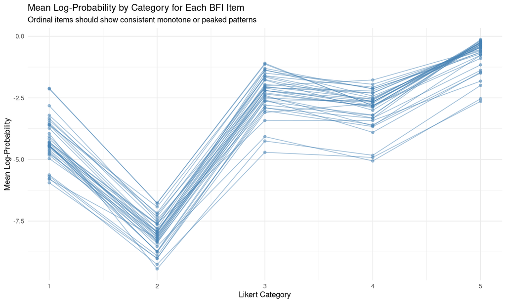

```r
item_lps <- bfi %>%
  group_by(item_id) %>%
  summarise(across(starts_with("logprob_"), ~ mean(.x, na.rm = TRUE)),
            n = n(),
            .groups = "drop") %>%
  filter(n >= 2)  # need at least 2 observations

item_lps_long <- item_lps %>%
  pivot_longer(cols = starts_with("logprob_"),
               names_to = "category",
               values_to = "mean_logprob") %>%
  mutate(k = as.integer(str_extract(category, "\\d+")))

ggplot(item_lps_long, aes(x = k, y = mean_logprob, group = item_id)) +
  geom_line(alpha = 0.5, color = "steelblue") +
  geom_point(alpha = 0.5, color = "steelblue") +
  labs(title = "Mean Log-Probability by Category for Each BFI Item",
       subtitle = "Ordinal items should show consistent monotone or peaked patterns",
       x = "Likert Category", y = "Mean Log-Probability") +
  theme_minimal()
```

### Classifying items as ordinal vs. nominal

We check whether the logprob-derived probabilities peak at a single mode and decay on both sides (ordinal/GRM-like) vs. showing non-monotone patterns (nominal-like).

```r
classify_item <- function(mean_lps) {
  # Convert to probabilities
  probs <- exp(mean_lps)
  probs <- probs / sum(probs)
  mode_k <- which.max(probs)

  # Check monotonicity on each side of mode
  left_ok <- if (mode_k == 1) TRUE else all(diff(probs[1:mode_k]) >= 0)
  right_ok <- if (mode_k == 5) TRUE else all(diff(probs[mode_k:5]) <= 0)

  unimodal <- left_ok & right_ok

  # Check if categories 1-5 have strictly ordered logprobs
  # (strong ordinality — not required, but informative)
  strictly_ordered <- all(diff(mean_lps) > 0) | all(diff(mean_lps) < 0)

  tibble(mode_k = mode_k, unimodal = unimodal,
         strictly_ordered = strictly_ordered,
         prob_spread = max(probs) - min(probs))
}

item_classes <- item_lps %>%
  rowwise() %>%
  mutate(classify_item(c(logprob_1, logprob_2, logprob_3,
                         logprob_4, logprob_5))) %>%
  ungroup()

cat(sprintf("Items with unimodal logprob profile: %d/%d (%.0f%%)\n",
            sum(item_classes$unimodal), nrow(item_classes),
            100 * mean(item_classes$unimodal)))
```

```
## Items with unimodal logprob profile: 0/37 (0%)
```

```r
cat(sprintf("Items with strictly ordered logprobs: %d/%d (%.0f%%)\n",
            sum(item_classes$strictly_ordered), nrow(item_classes),
            100 * mean(item_classes$strictly_ordered)))
```

```
## Items with strictly ordered logprobs: 0/37 (0%)
```

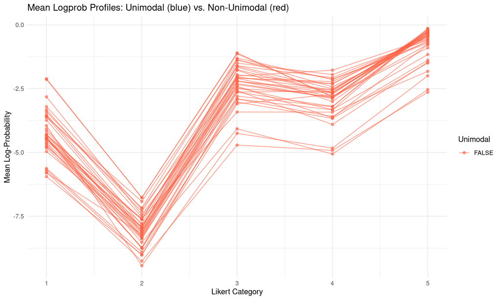

```r
item_lps_long <- item_lps_long %>%
  left_join(item_classes %>% select(item_id, unimodal), by = "item_id")

ggplot(item_lps_long, aes(x = k, y = mean_logprob,
                          group = item_id, color = unimodal)) +
  geom_line(alpha = 0.6) +
  geom_point(alpha = 0.6) +
  scale_color_manual(values = c("TRUE" = "steelblue", "FALSE" = "tomato")) +
  labs(title = "Mean Logprob Profiles: Unimodal (blue) vs. Non-Unimodal (red)",
       x = "Likert Category", y = "Mean Log-Probability",
       color = "Unimodal") +
  theme_minimal()
```

## Part 2: Row-Level NRM Diagnostics

Each row gives us a full 5-category probability distribution from the LLM. We can analyze these directly as if they were NRM category response functions evaluated at a particular (unknown) trait level.

### Entropy of response distributions

Low entropy = model is confident in one category (sharp discrimination). High entropy = model spreads probability across categories (low discrimination).

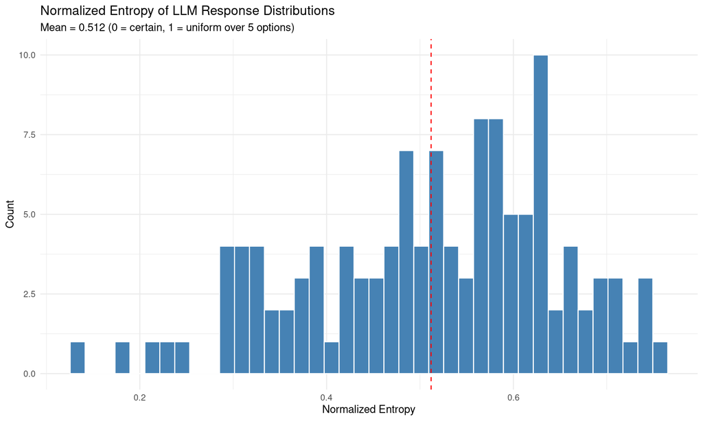

```r
bfi <- bfi %>%
  rowwise() %>%
  mutate(
    entropy = {
      p <- c(prob_1, prob_2, prob_3, prob_4, prob_5)
      p <- p / sum(p)  # renormalize to valid options only
      p <- p[p > 0]
      -sum(p * log(p))
    },
    max_entropy = log(5)
  ) %>%
  ungroup() %>%
  mutate(normed_entropy = entropy / max_entropy)

ggplot(bfi, aes(x = normed_entropy)) +
  geom_histogram(bins = 40, fill = "steelblue", color = "white") +
  geom_vline(xintercept = mean(bfi$normed_entropy), linetype = "dashed",
             color = "red") +
  labs(title = "Normalized Entropy of LLM Response Distributions",
       subtitle = sprintf("Mean = %.3f (0 = certain, 1 = uniform over 5 options)",
                          mean(bfi$normed_entropy)),
       x = "Normalized Entropy", y = "Count") +
  theme_minimal()
```

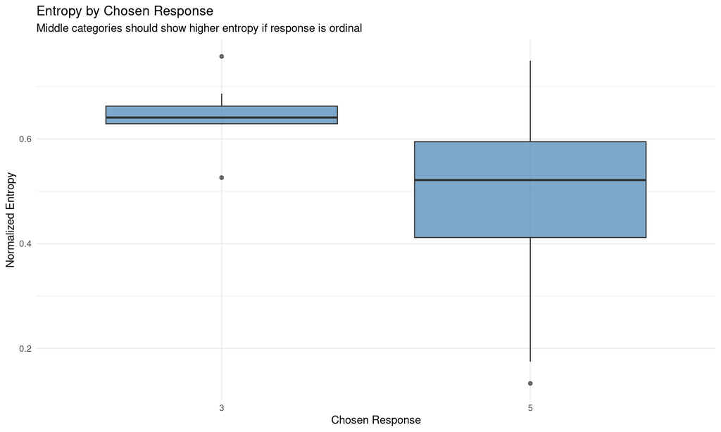

```r
ggplot(bfi, aes(x = factor(response), y = normed_entropy)) +
  geom_boxplot(fill = "steelblue", alpha = 0.7) +
  labs(title = "Entropy by Chosen Response",
       subtitle = "Middle categories should show higher entropy if response is ordinal",
       x = "Chosen Response", y = "Normalized Entropy") +
  theme_minimal()
```

### Implied category response curves

In IRT, category response curves show $P(X=k|\theta)$ as a function of the latent trait. We don’t observe $\theta$ directly, but we can use the logprob for the highest category (`logprob_5`) as a proxy — it should correlate with whatever latent “agreeableness” the model is expressing.

We plot the probability of each category as a function of this proxy trait.

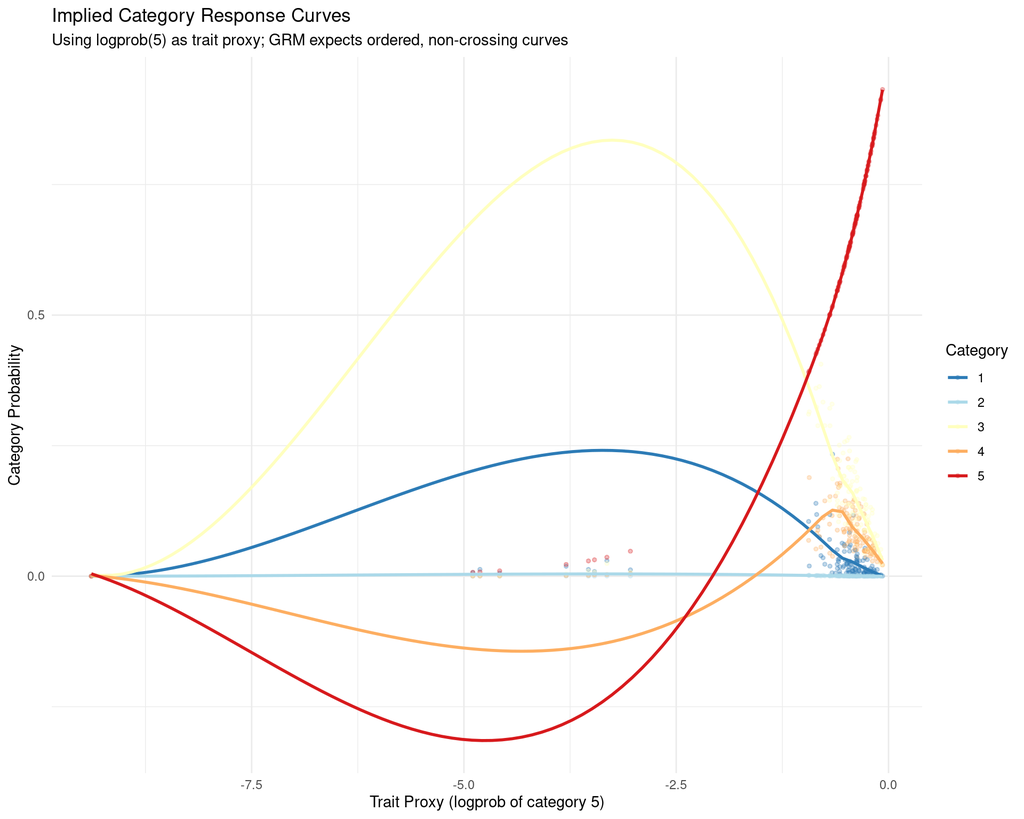

```r
bfi_crc <- bfi %>%
  mutate(theta_proxy = logprob_5) %>%
  select(theta_proxy, prob_1:prob_5, response, item_id) %>%
  pivot_longer(cols = prob_1:prob_5,
               names_to = "category",
               values_to = "prob") %>%
  mutate(k = as.integer(str_extract(category, "\\d+")))

ggplot(bfi_crc, aes(x = theta_proxy, y = prob, color = factor(k))) +
  geom_point(alpha = 0.3, size = 1) +
  geom_smooth(method = "loess", se = FALSE, linewidth = 1) +
  scale_color_brewer(palette = "RdYlBu", direction = -1) +
  labs(title = "Implied Category Response Curves",
       subtitle = "Using logprob(5) as trait proxy; GRM expects ordered, non-crossing curves",
       x = "Trait Proxy (logprob of category 5)",
       y = "Category Probability",
       color = "Category") +
  theme_minimal()
```

### Do curves cross in ordinal order?

For GRM suitability, the category curves should cross in order: as the trait increases, lower categories yield to higher ones sequentially.

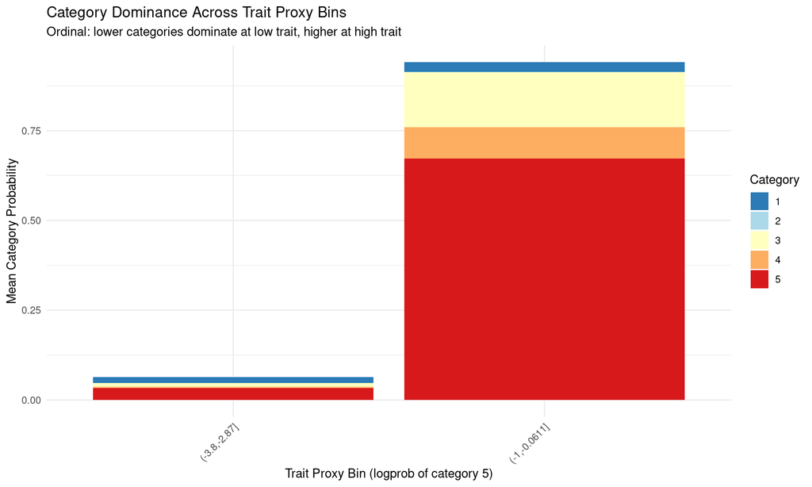

```r
# At each level of the trait proxy, which category has highest probability?
bfi_dominant <- bfi %>%
  mutate(theta_proxy = logprob_5,
         theta_bin = cut(theta_proxy, breaks = 10)) %>%
  group_by(theta_bin) %>%
  summarise(across(prob_1:prob_5, mean, na.rm = TRUE),
            n = n(), .groups = "drop") %>%
  filter(n >= 3) %>%
  pivot_longer(prob_1:prob_5, names_to = "category",
               values_to = "mean_prob") %>%
  mutate(k = as.integer(str_extract(category, "\\d+")))

ggplot(bfi_dominant, aes(x = theta_bin, y = mean_prob,
                         fill = factor(k))) +
  geom_col(position = "stack") +
  scale_fill_brewer(palette = "RdYlBu", direction = -1) +
  labs(title = "Category Dominance Across Trait Proxy Bins",
       subtitle = "Ordinal: lower categories dominate at low trait, higher at high trait",
       x = "Trait Proxy Bin (logprob of category 5)",
       y = "Mean Category Probability",
       fill = "Category") +
  theme_minimal() +
  theme(axis.text.x = element_text(angle = 45, hjust = 1))
```

## Part 3: Formal NRM Fit (where data permits)

The sample is sparse (most SPIDs answered only 1 BFI item), so a full IRT calibration isn’t reliable. We attempt it on items with the most observations to get a directional read on parameter ordering.

```r
# Find items with enough observations
item_counts <- bfi %>% count(item_id, sort = TRUE)
cat("Items by number of observations:\n")
```

```
## Items by number of observations:
```

```r
print(head(item_counts, 20))
```

```
## # A tibble: 20 × 2
##    item_id     n
##    <chr>   <int>
##  1 bf30        6
##  2 bf4         6
##  3 bf12        5
##  4 bf23        5
##  5 bf29        5
##  6 bf33        5
##  7 bf5         5
##  8 bf8         5
##  9 bf24        4
## 10 bf28        4
## 11 bf43        4
## 12 bf10        3
## 13 bf19        3
## 14 bf20        3
## 15 bf21        3
## 16 bf27        3
## 17 bf32        3
## 18 bf34        3
## 19 bf36        3
## 20 bf40        3
```

```r
# We need items answered by the same SPIDs for a person-by-item matrix
# Check the densest subset
top_items <- item_counts %>% filter(n >= 3) %>% pull(item_id)
cat(sprintf("\nItems with >= 3 observations: %d\n", length(top_items)))
```

```
##
## Items with >= 3 observations: 22
```

```r
# Build person-by-item matrix from available data
bfi_sub <- bfi %>%
  filter(item_id %in% top_items) %>%
  select(spid, item_id, response) %>%
  pivot_wider(names_from = item_id, values_from = response)

resp_mat <- bfi_sub %>% select(-spid) %>% as.data.frame()

# Count completeness
pct_complete <- mean(!is.na(as.matrix(resp_mat)))
cat(sprintf("Response matrix: %d persons x %d items, %.1f%% complete\n",
            nrow(resp_mat), ncol(resp_mat), 100 * pct_complete))
```

```
## Response matrix: 85 persons x 22 items, 4.7% complete
```

```r
# Only fit if we have enough data
if (pct_complete > 0.05 & nrow(resp_mat) >= 20 & ncol(resp_mat) >= 5) {
  # Fit nominal response model
  nrm_mod <- mirt(resp_mat, model = 1, itemtype = "nominal",
                  verbose = FALSE)
  cat("\nNominal Response Model:\n")
  print(summary(nrm_mod))

  # Extract item parameters
  nrm_params <- coef(nrm_mod, simplify = TRUE)
  cat("\nItem parameters (ak slopes — ordered = GRM-suitable):\n")
  print(nrm_params$items)

  # Also fit GRM for comparison
  # Recode to ensure ordered factor levels
  resp_grm <- resp_mat
  for (col in names(resp_grm)) {
    resp_grm[[col]] <- factor(resp_grm[[col]], levels = 1:5, ordered = TRUE)
  }

  tryCatch({
    grm_mod <- mirt(resp_mat, model = 1, itemtype = "graded",
                    verbose = FALSE)
    cat("\nGraded Response Model:\n")
    print(summary(grm_mod))

    # Compare fit
    cat("\n=== Model Comparison ===\n")
    cat(sprintf("NRM AIC: %.1f  BIC: %.1f\n",
                nrm_mod@Fit$AIC, nrm_mod@Fit$BIC))
    cat(sprintf("GRM AIC: %.1f  BIC: %.1f\n",
                grm_mod@Fit$AIC, grm_mod@Fit$BIC))
    cat(sprintf("Lower AIC/BIC = better fit.\n"))
  }, error = function(e) {
    cat("\nGRM fitting failed (likely due to sparse data):", e$message, "\n")
  })
} else {
  cat("Insufficient data density for IRT model fitting.\n")
  cat("Full replication run needed for formal NRM vs GRM comparison.\n")
}
```

```
## Insufficient data density for IRT model fitting.
## Full replication run needed for formal NRM vs GRM comparison.
```